# Lista de Exercícios 01 - Curso de Modelagem Linear

Marcio Vakassugui

2022-08-17

## Dados

O banco de dados `Boston` apresenta registros de valores medianos das casas (`medv`) de 506 bairros de Boston. O objetivo é identificar quais das 13 variáveis explicativas estão associadas com esses valores e usá-las para fazer predições de preços das casas.

```r
View(MASS::Boston)
dplyr::glimpse(MASS::Boston)
```

```
## Rows: 506
## Columns: 14
## $ crim    <dbl> 0.00632, 0.02731, 0.02729, 0.03237, 0.06905, 0.02985, 0.08829,…
## $ zn      <dbl> 18.0, 0.0, 0.0, 0.0, 0.0, 0.0, 12.5, 12.5, 12.5, 12.5, 12.5, 1…
## $ indus   <dbl> 2.31, 7.07, 7.07, 2.18, 2.18, 2.18, 7.87, 7.87, 7.87, 7.87, 7.…
## $ chas    <int> 0, 0, 0, 0, 0, 0, 0, 0, 0, 0, 0, 0, 0, 0, 0, 0, 0, 0, 0, 0, 0,…
## $ nox     <dbl> 0.538, 0.469, 0.469, 0.458, 0.458, 0.458, 0.524, 0.524, 0.524,…
## $ rm      <dbl> 6.575, 6.421, 7.185, 6.998, 7.147, 6.430, 6.012, 6.172, 5.631,…
## $ age     <dbl> 65.2, 78.9, 61.1, 45.8, 54.2, 58.7, 66.6, 96.1, 100.0, 85.9, 9…
## $ dis     <dbl> 4.0900, 4.9671, 4.9671, 6.0622, 6.0622, 6.0622, 5.5605, 5.9505…
## $ rad     <int> 1, 2, 2, 3, 3, 3, 5, 5, 5, 5, 5, 5, 5, 4, 4, 4, 4, 4, 4, 4, 4,…
## $ tax     <dbl> 296, 242, 242, 222, 222, 222, 311, 311, 311, 311, 311, 311, 31…
## $ ptratio <dbl> 15.3, 17.8, 17.8, 18.7, 18.7, 18.7, 15.2, 15.2, 15.2, 15.2, 15…
## $ black   <dbl> 396.90, 396.90, 392.83, 394.63, 396.90, 394.12, 395.60, 396.90…
## $ lstat   <dbl> 4.98, 9.14, 4.03, 2.94, 5.33, 5.21, 12.43, 19.15, 29.93, 17.10…
## $ medv    <dbl> 24.0, 21.6, 34.7, 33.4, 36.2, 28.7, 22.9, 27.1, 16.5, 18.9, 15…
```

```r
# Descrição das variáveis
utils::help(Boston)
```

## Exercício 1

Faça um gráfico de dispersão entre `medv` e `rm`.

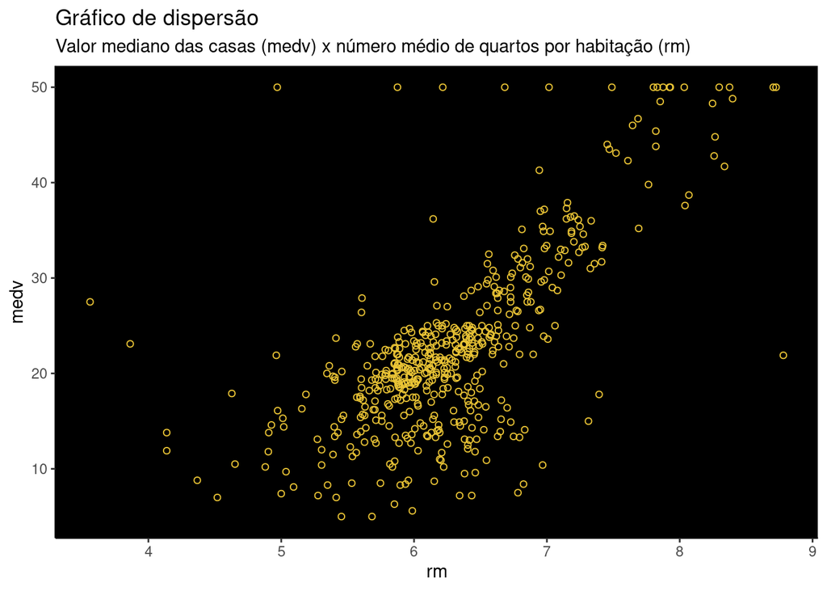

fig01 - gráfico de dispersão dos pares valor mediano das casas e número médio de quartos por habitação

```r
grafico_exercicio_01 <- MASS::Boston |>
   dplyr::select(medv, rm) |>
   ggplot2::ggplot()+
   ggplot2::aes(y = medv, x = rm)+
   ggplot2::geom_point(shape = 1, color = '#EAC435')+
   ggplot2::labs(title = 'Gráfico de dispersão',
        subtitle = 'Valor mediano das casas (medv) x número médio de quartos por habitação (rm)')+
   ggplot2::theme_classic()+
   ggplot2::theme(panel.background = ggplot2::element_rect(fill = '#000000'))

grafico_exercicio_01
```

## Exercício 2

Ajuste um modelo de regressão linear simples utilizando `medv` como resposta e `rm` como explicativa e guarde em objeto chamado `mod_simples`. Consulte o `summary(mod_simples)` em seguida.

```r
mod_simples <- stats::lm(medv ~ rm, data = MASS::Boston)

summary(mod_simples)
```

```
##
## Call:
## stats::lm(formula = medv ~ rm, data = MASS::Boston)
##
## Residuals:
##     Min      1Q  Median      3Q     Max
## -23.346  -2.547   0.090   2.986  39.433
##
## Coefficients:
##             Estimate Std. Error t value Pr(>|t|)
## (Intercept)  -34.671      2.650  -13.08   <2e-16 ***
## rm             9.102      0.419   21.72   <2e-16 ***
## ---
## Signif. codes:  0 '***' 0.001 '**' 0.01 '*' 0.05 '.' 0.1 ' ' 1
##
## Residual standard error: 6.616 on 504 degrees of freedom
## Multiple R-squared:  0.4835, Adjusted R-squared:  0.4825
## F-statistic: 471.8 on 1 and 504 DF,  p-value: < 2.2e-16
```

## Exercício 3

Sabendo que `medv` é o preço mediano das habitações do bairro e o `rm` é o número médio de quartos por habitação,

1. interprete o parâmetro `(Intercept)`.

No exercício 02, ajustamos o modelo de regressão linear considerando `medv` como variável resposta e `rm` como variável explicativa. O objetivo era encontrar as **estimadores dos mínimos quadrados**, ou seja, os parâmetros $\hat{\beta }_{0}$ e $\hat{\beta }_{1}$, de modo que o modelo linear resultante fosse o mais próximo possível dos n pontos de dados. Foi utilizada a abordagem dos mínimos quadrados, em que um ajuste foi feito minimizando a soma dos erros ao quadrado. O parâmetro `intercept` obtido pela função lm do pacote ‘stats’ corresponde ao parâmetro $\hat{\beta }_{0}$, e pode ser obtido pela seguinte equação de estimação:

$$\hat{\beta }_{0} = \bar{y} -
\hat{\beta }_{1}\bar{x}$$
O `intercept` representa o valor provável do preço mediano das habitações para aquelas com o número médio de quartos igual a zero.

2. interprete o parâmetro `rm`.

O parâmetro `rm`, conhecido por `slope`, representa o parâmetro $\hat{\beta }_{1}$ do modelo e pode ser obtido pela equação de estimação:

$$\hat{\beta }_{1} =
\frac{\sum_{i=1}^{n}\left ( x_{i} - \bar{x} \right
)(y_{i}-\bar{y})}{\sum_{i=1}^{n }(x_{i} - \bar{x})^{2}}$$

Este parâmetro representa o aumento esperado do preço mediano das habitações para cada aumento na média de quartos de uma unidade no total de quartos da habitação.

3. o número de quartos está associado com o valor da habitação? Por quê?

Sim, o número de quartos está associado com o valor da habitação.

Vamos analisar esta questão, partindo do seguinte teste de hipótese:

‘O número médio de quartos por habitação **não** possui associação com o valor mediano das casas’

$\left\{ \begin{array}{cl} H0 & : \ \hat{\beta }_{1} = 0 \\ Ha & : \ \hat{\beta }_{1} \neq 0 \end{array} \right.$

Ao analisar os resultados obtidos no exercício 02, observa-se que que o `t-value` obtido para o parâmetro `rm` (número médio de quartos por habitação) foi de 21,72, o que torna absurda a hipótese nula, pois este valor afasta-se significativamente da zona provável de valores para a hipótese analisada.

O `valor-p`, que representa a probabilidade de encontrarmos o valor de 21,72 (*t-value*) na zona provável de valores para a hipótese de que o número médio de quartos por habitação **não** possui associação com o valor mediano das casas é muito próximo de zero, portanto podemos **refutar** a hipótese nula.

Conclui-se, portanto, que o número médio de quartos está associado ao valor mediano das habitações.

## Exercício 4

Consulte as saídas das funções

- `coef(mod_simples)`
- `confint(mod_simples)`
- `predict(mod_simples)`
- `predict(mod_simples, interval = "confidence")`
- `augment(mod_simples)`

```r
stats::coef(mod_simples)
```

```
## (Intercept)          rm
##  -34.670621    9.102109
```

a funçao coef extrai coeficientes de objetos que retornam de funções de modelagem.

```r
confint(mod_simples)
```

```
##                  2.5 %     97.5 %
## (Intercept) -39.876641 -29.464601
## rm            8.278855   9.925363
```

A funçao confint do pacote stats calcula os intervalos de confiança para um ou mais parâmetros em um modelo ajustado.

Esta é uma função genérica. O método padrão presume normalidade, e precisa que as funções coef e vcov estejam disponíveis.

```r
predict(mod_simples) |>
  head(n = 100)
```

```
##        1        2        3        4        5        6        7        8
## 25.17575 23.77402 30.72803 29.02594 30.38215 23.85594 20.05126 21.50760
##        9       10       11       12       13       14       15       16
## 16.58335 19.97844 23.37353 20.02395 18.93170 19.47783 20.81584 18.43108
##       17       18       19       20       21       22       23       24
## 19.35040 19.85101 14.99049 17.45716 16.02813 19.62346 21.23453 18.23994
##       25       26       27       28       29       30       31       32
## 19.25027 16.29209 18.23994 20.36983 24.44758 26.07685 17.32973 20.59738
##       33       34       35       36       37       38       39       40
## 19.48693 17.22050 20.81584 19.33219 18.49480 18.57672 19.63256 25.35779
##       41       42       43       44       45       46       47       48
## 29.26259 26.95066 21.48029 21.86258 20.57008 17.04756 17.99418 20.21510
##       49       50       51       52       53       54       55       56
## 14.47167 16.31939 19.60526 20.98878 24.59321 19.92383 18.92260 31.31057
##       57       58       59       60       61       62       63       64
## 23.42814 27.36935 21.26184 19.27758 17.58459 19.63256 24.09259 26.87784
##       65       66       67       68       69       70       71       72
## 29.99076 22.58164 18.00328 18.83158 16.24658 18.89529 23.73761 19.58705
##       73       74       75       76       77       78       79       80
## 20.53367 22.17205 22.42691 22.54524 22.48152 21.21633 22.05372 18.79517
##       81       82       83       84       85       86       87       88
## 26.55927 25.57624 22.69087 21.46209 23.48275 25.67636 20.07856 21.04339
##       89       90       91       92       93       94       95       96
## 29.10786 29.76321 23.73761 23.62839 23.96517 21.86258 22.20846 25.63085
##       97       98       99      100
## 21.42568 38.77430 36.50787 32.83062
```

```r
predict(mod_simples, interval = "confidence") |>
  head(n = 100)
```

```
##          fit      lwr      upr
## 1   25.17575 24.55039 25.80110
## 2   23.77402 23.18536 24.36269
## 3   30.72803 29.78817 31.66790
## 4   29.02594 28.20203 29.84984
## 5   30.38215 29.46676 31.29755
## 6   23.85594 23.26582 24.44606
## 7   20.05126 19.43134 20.67118
## 8   21.50760 20.92234 22.09285
## 9   16.58335 15.79375 17.37296
## 10  19.97844 19.35611 20.60078
## 11  23.37353 22.79069 23.95637
## 12  20.02395 19.40313 20.64477
## 13  18.93170 18.26837 19.59503
## 14  19.47783 18.83730 20.11835
```

[output cut: 86 more lines]

```r
broom::augment(mod_simples)
```

```
## # A tibble: 506 × 8
##     medv    rm .fitted  .resid    .hat .sigma     .cooksd .std.resid
##    <dbl> <dbl>   <dbl>   <dbl>   <dbl>  <dbl>       <dbl>      <dbl>
##  1  24    6.58    25.2 -1.18   0.00231   6.62 0.0000367      -0.178
##  2  21.6  6.42    23.8 -2.17   0.00205   6.62 0.000111       -0.329
##  3  34.7  7.18    30.7  3.97   0.00523   6.62 0.000952        0.602
##  4  33.4  7.00    29.0  4.37   0.00402   6.62 0.000885        0.662
##  5  36.2  7.15    30.4  5.82   0.00496   6.62 0.00194         0.882
##  6  28.7  6.43    23.9  4.84   0.00206   6.62 0.000555        0.733
##  7  22.9  6.01    20.1  2.85   0.00227   6.62 0.000212        0.431
##  8  27.1  6.17    21.5  5.59   0.00203   6.62 0.000727        0.846
##  9  16.5  5.63    16.6 -0.0834 0.00369   6.62 0.000000295    -0.0126
## 10  18.9  6.00    20.0 -1.08   0.00229   6.62 0.0000306      -0.163
## # … with 496 more rows
## # ℹ Use `print(n = ...)` to see more rows
```

## Exercício 5

Usando o data.frame gerado por `augment(mod_simples)` faça um gráfico de `medv` versus `rm` e em seguida desenhe a reta ajustada do `mod_simples`.

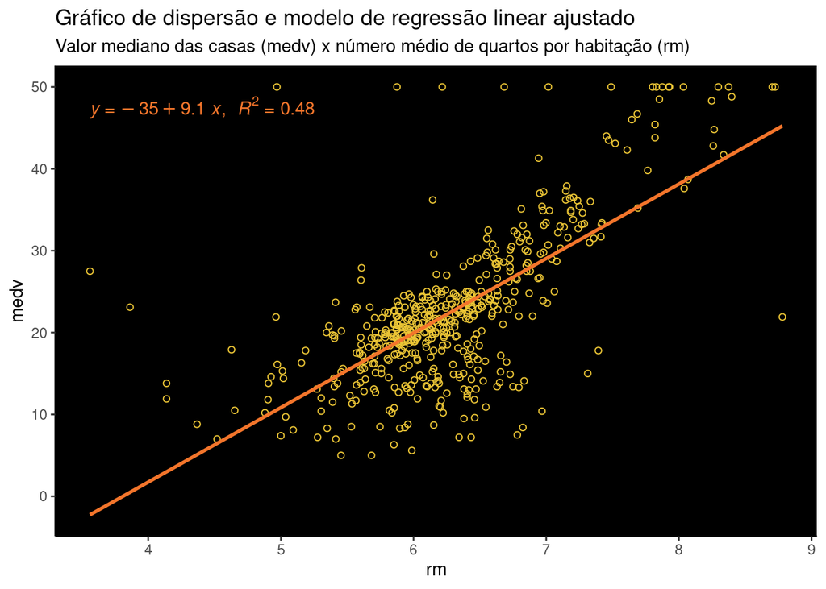

```r
graf_ex05 <- broom::augment(mod_simples) |>
  dplyr::select(medv, rm) |>
  ggplot2::ggplot() +
  ggplot2::aes(
    y = medv,
    x = rm
  ) +
  ggplot2::geom_point(shape = 1, color = "#EAC435") +
  ggplot2::geom_smooth(method = "lm", se = FALSE, color = "#F3752B") +
  ggplot2::labs(
    title = "Gráfico de dispersão e modelo de regressão linear ajustado",
    subtitle = "Valor mediano das casas (medv) x número médio de quartos por habitação (rm)"
  ) +
  ggpubr::stat_regline_equation(ggplot2::aes(label = paste(..eq.label..,
    ..rr.label..,
    sep = "*plain(\",\")~~"
  )),
  color = "#F3752B"
  ) +
  ggplot2::theme_classic() +
  ggplot2::theme(panel.background = ggplot2::element_rect(fill = "#000000"))


graf_ex05
```

## Exercício 6

Faça um gráfico de resíduos. Coloque os **resíduos** no eixo Y e os **valores ajustados** no eixo X.

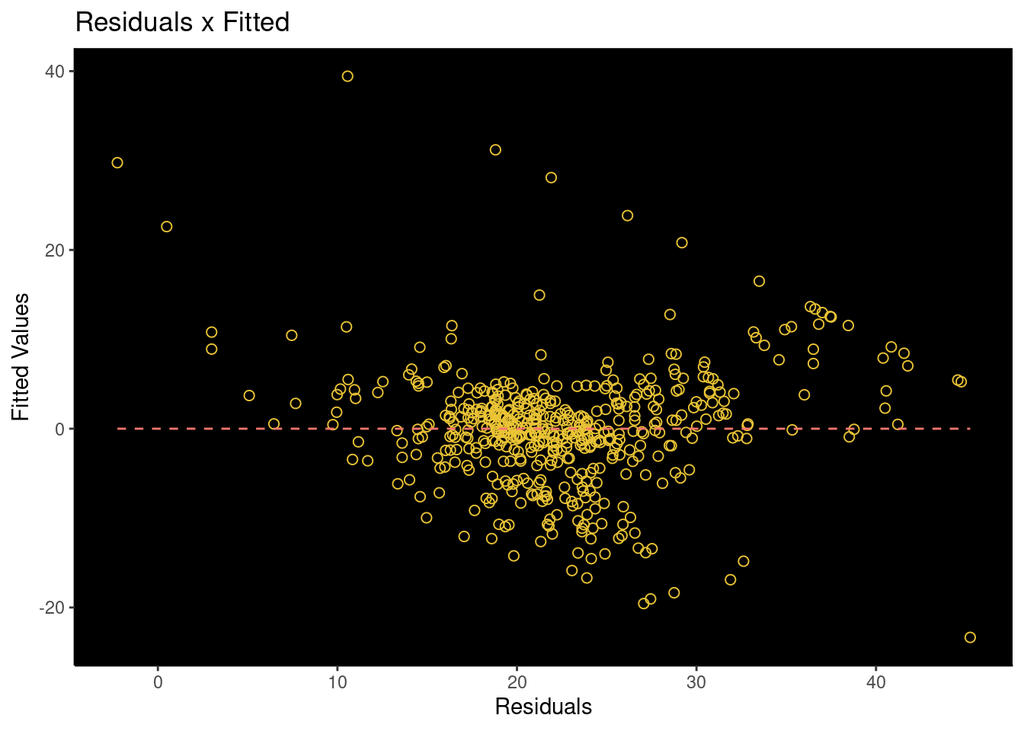

```r
residuos <- broom::augment(mod_simples) |>
  dplyr::select(.resid, .fitted) |>
  ggplot2::ggplot()+
  ggplot2::aes(x = .fitted, y = .resid)+
  ggplot2::geom_point(shape = 1, size = 2, color = '#EAC435')+
  ggplot2::geom_line(ggplot2::aes(x = .fitted, y = 0, color = 'red'),
                     linetype = 2)+
  ggplot2::labs(
    title = 'Residuals x Fitted',
    x = 'Residuals',
    y = 'Fitted Values'
  )+
  ggplot2::theme_classic()+
  ggplot2::theme(
    panel.background = ggplot2::element_rect(fill = '#000000'),
    legend.position = 'none')

residuos
```

```r
#ver <- plot(mod_simples, col = '#FFFFFF', bg = par('bg'))
```

## Exercício 7

Observe os gráficos de `plot(mod_simples)`.

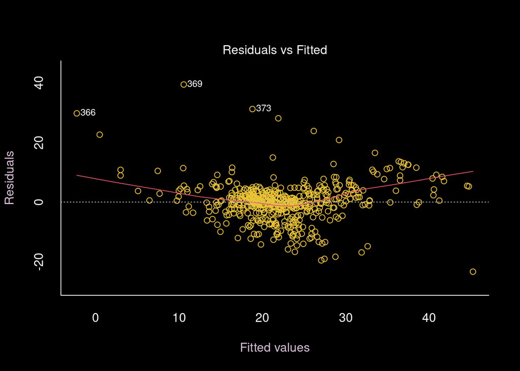

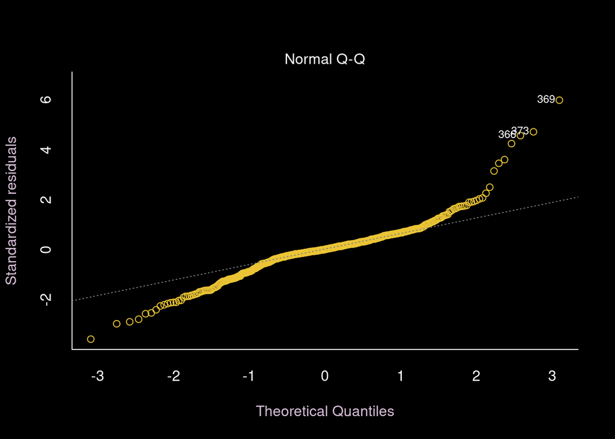

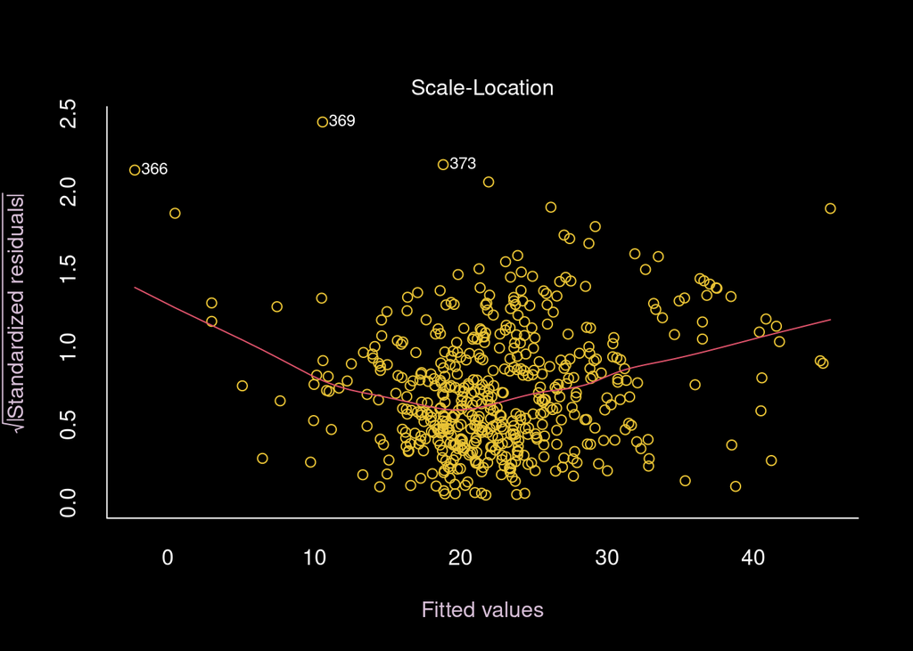

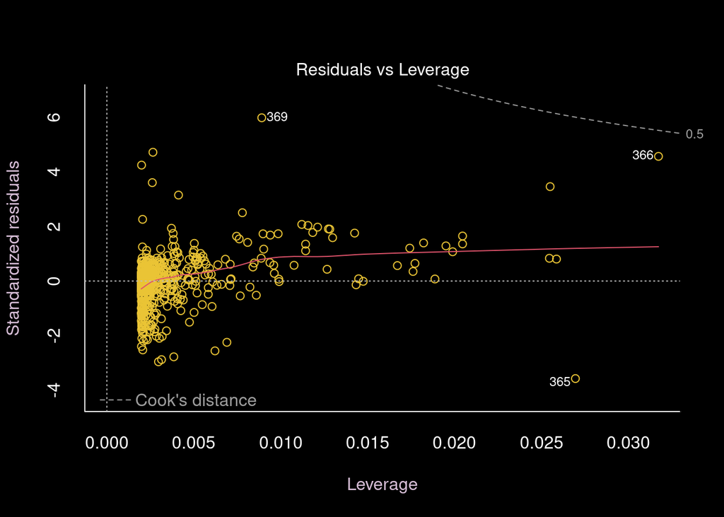

```r
op <- par(bg = '#000000')

graphics::par(mfrow = c(1,1), bty = 'l', col = '#FFFFFF')
plot(mod_simples, bg = par('bg'), col = '#EAC435', col.axis = "#FFFFFF", col.lab = "thistle")
```

Apenas pela inspeção visual, responda: existem outliers? Eles são pontos de alavanca?

A existência de outliers e de pontos de alavancagem pode ser analisada por meio do gráfico ‘Residuals vs Leverage’.

De acordo com Morettin and Singer, Julio da Motta (2022), ‘Uma das ferramentas mais úteis para a avaliação da qualidade do ajuste de modelos de regressão é o **gráfico de resíduos** em que os resíduos são dispostos no eixo das ordenadas e os correspondentes valores da variável explicativa no eixo das abscissas (..) Os resíduos padronizados são adimensionais e têm variância igual a 1, independentemente da variância dos erros. Além disso, para erros com distribuição normal, cerca de 99% dos resíduos padronizados tem valor entre -3 e +3’.

O gráfico Normal Q-Q ou o teste de Shapiro-Wilk permitem verificar se os erros possuem distribuição normal.

```r
stats::shapiro.test(mod_simples[['residuals']])
```

```
##
##  Shapiro-Wilk normality test
##
## data:  mod_simples[["residuals"]]
## W = 0.92046, p-value = 1.088e-15
```

Levando em conta que o teste de Shapiro-Wilk considera:

H0: distribuição dos dados = normal ——-> p > 0,05 Ha: distribuição dos dados != normal ——> p <=0,05

Logo, rejeitando a hipótese nula temos que a distribuição dos resíduos não é normal. A mesma conclusão pode ser obtida analisando o Q-Q plot.

A partir do gráfico ‘Residuals x Leverage’, os dados que extrapolam os valores de -3 e +3 são identificados como *outliers* como os casos #369, #366 e #365. Estes números representam o número da linha do dado na base de dados. Entretanto, pelo gráfico não existem pontos influentes ou pontos alavanca (*high leverage points*). Note que pouco vemos as linhas de distância de Cook (linha tracejada no canto superior direito) e todos os casos estão dentro das linhas de distância de Cook

```r
# EXISTÊNCIA DE OUTLIERS NOS RESÍDUOS
summary(stats::rstandard(mod_simples))
```

```
##      Min.   1st Qu.    Median      Mean   3rd Qu.      Max.
## -3.577155 -0.385463  0.013583  0.000682  0.452185  5.986852
```

Os mínimos e os máximo extrapolam os limites -3 e +3, o que indica a existência de pontos discrepantes.

## Exercício 8

Ajuste um modelo `mod_multiplo` para `medv` explicado por `rm` e `crim`. Consulte o `summary(mod_multiplo)` em seguida.

```r
mod_multiplo <- stats::lm(medv ~ rm + crim, data = MASS::Boston)

summary(mod_multiplo)
```

```
##
## Call:
## stats::lm(formula = medv ~ rm + crim, data = MASS::Boston)
##
## Residuals:
##     Min      1Q  Median      3Q     Max
## -21.608  -2.835  -0.380   2.592  38.839
##
## Coefficients:
##              Estimate Std. Error t value Pr(>|t|)
## (Intercept) -29.24472    2.58809 -11.300   <2e-16 ***
## rm            8.39107    0.40485  20.726   <2e-16 ***
## crim         -0.26491    0.03307  -8.011    8e-15 ***
## ---
## Signif. codes:  0 '***' 0.001 '**' 0.01 '*' 0.05 '.' 0.1 ' ' 1
##
## Residual standard error: 6.237 on 503 degrees of freedom
## Multiple R-squared:  0.542,  Adjusted R-squared:  0.5401
## F-statistic: 297.6 on 2 and 503 DF,  p-value: < 2.2e-16
```

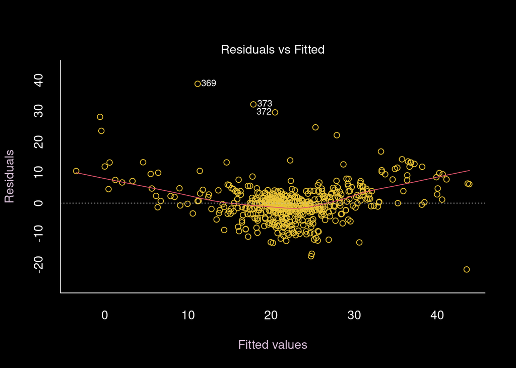

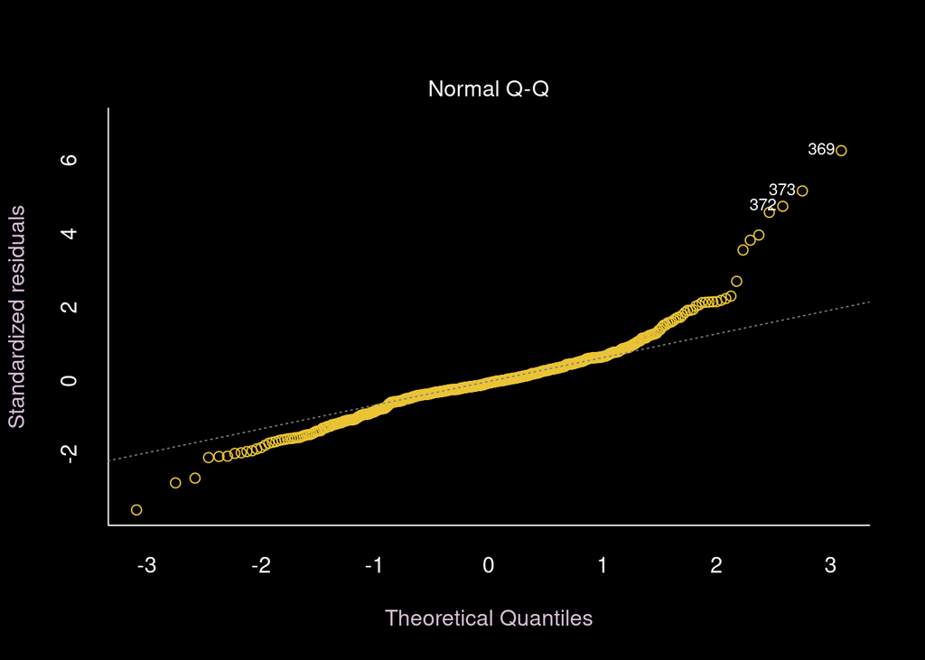

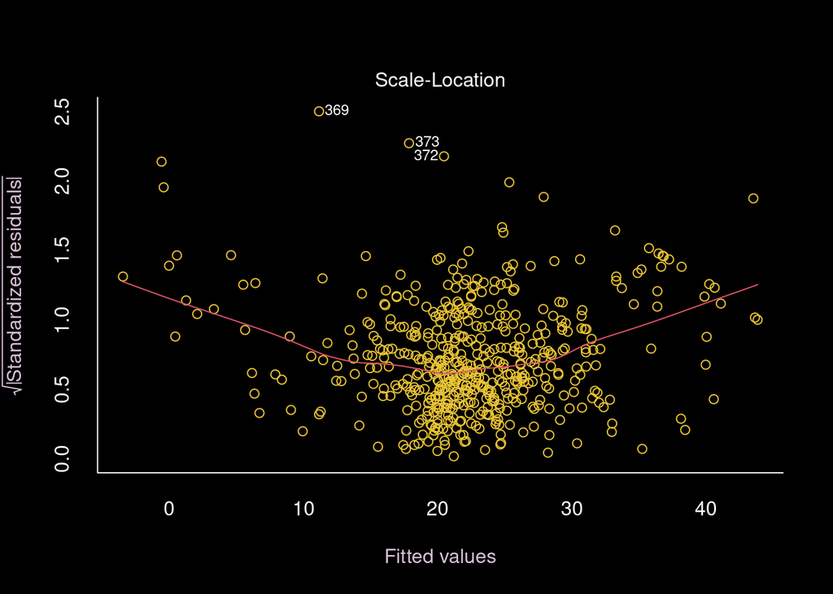

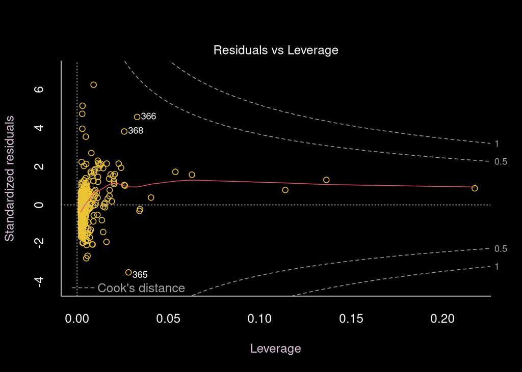

```r
op <- par(bg = '#000000')

graphics::par(mfrow = c(1,1), bty = 'l', col = '#FFFFFF')
plot(mod_multiplo, bg = par('bg'), col = '#EAC435', col.axis = "#FFFFFF", col.lab = "thistle")
```

Conforme o *post* “Understanding Diagnostic Plots for Linear Regression Analysis | University of Virginia Library Research Data Services + Sciences” (n.d.), de Bommae King, da Biblioteca da Universidade da Virginia, o gráfico ‘Residuals x Fitted’ nos mostra que a existência de uma relação linear entre a variável resposta e a variável explicativa ocorre quando encontramos resíduos igualmente espalhados em torno de uma linha horizontal sem padrões distintos, sendo isto é uma boa indicação de que as variáveis possuem relação linear.

## Exercício 9

Qual modelo ficou melhor: `mod_simples` ou `mod_multiplo`? Qual critério você utilizou para decidir o melhor?

Conforme Morettin and Singer, Julio da Motta (2022), ’Uma vez ajustado o modelo, convém avaliar a qualidade do ajuste e um dos indicadores mais utilizados para essa finalidade é o **coeficiente de determinação** definido como:

$$R^{2} = \frac{SQTot - SQRes}{SQTot} =
\frac{SQReg}{SQTot} = 1 - \frac{SQRes}{SQTot},$$
(..) Em essência, esse coeficiente mede a porcentagem da variação total dos valores da variável resposta (yi) em relação à sua média ($\bar{y}$) explicada pelo modelo de regressão’.

Segundo Pianezzer (2020), ‘pode-se provar que R<sup>2</sup> está contido entre 0 e 1. Alguns livros chamam de *coeficiente de determinação* o termo’ R, tal que $-1 \le R \le 1$; entretanto, utilizar R<sup>2</sup>, tal que $0 \le R^{2} \le 1$ facilita a análise ao evitar operar com números negativos. Dessa forma, podemos afirmar que quanto mais $R^{2} \to 1$, mais forte é o poder explicativo do modelo linear. Quanto mais $R^{2} \to 0$, menos podemos confiar no modelo, visto que os dados não se aproximam da reta.”

Na tabela abaixo, temos os resultados dos modelos de regressão linear simple e múltiplo.

```r
sjPlot::tab_model(mod_simples, mod_multiplo)
```

|  | medv |  |  | medv |  |  |
| --- | --- | --- | --- | --- | --- | --- |
| Predictors | Estimates | CI | p | Estimates | CI | p |
| (Intercept) | -34.67 | -39.88 – -29.46 | **<0.001** | -29.24 | -34.33 – -24.16 | **<0.001** |
| rm | 9.10 | 8.28 – 9.93 | **<0.001** | 8.39 | 7.60 – 9.19 | **<0.001** |
| crim |  |  |  | -0.26 | -0.33 – -0.20 | **<0.001** |
| Observations | 506 |  |  | 506 |  |  |
| R<sup>2</sup> / R<sup>2</sup> adjusted | 0.484 / 0.483 |  |  | 0.542 / 0.540 |  |  |

O modelo `mod_multiplo` ficou melhor, considerando que possui melhor coeficiente de determinação ($R^{2}$) de 0,542, melhor que o obtido pelo modelos simples, cujo coeficiente de determinação foi de 0,48.

## Exercício 10

Ajuste um modelo `mod_completo` para `medv` explicado por todas as demais colunas. DICA: na fórmula `medv ~ .`, o ponto significa “todas as variáveis, tirando medv”.

1. Consulte o `summary(mod_completo)` em seguida.
2. Qual modelo ficou melhor: `mod_simples`, `mod_multiplo` ou `mod_completo`?
3. O valor estimado para o termo `rm` variou entre os três modelos? Por qual razão você acha que isso aconteceu?

```r
mod_completo <- stats::lm(medv ~ ., data = MASS::Boston)

summary(mod_completo)
```

```
##
## Call:
## stats::lm(formula = medv ~ ., data = MASS::Boston)
##
## Residuals:
##     Min      1Q  Median      3Q     Max
## -15.595  -2.730  -0.518   1.777  26.199
##
## Coefficients:
##               Estimate Std. Error t value Pr(>|t|)
## (Intercept)  3.646e+01  5.103e+00   7.144 3.28e-12 ***
## crim        -1.080e-01  3.286e-02  -3.287 0.001087 **
## zn           4.642e-02  1.373e-02   3.382 0.000778 ***
## indus        2.056e-02  6.150e-02   0.334 0.738288
## chas         2.687e+00  8.616e-01   3.118 0.001925 **
## nox         -1.777e+01  3.820e+00  -4.651 4.25e-06 ***
## rm           3.810e+00  4.179e-01   9.116  < 2e-16 ***
## age          6.922e-04  1.321e-02   0.052 0.958229
## dis         -1.476e+00  1.995e-01  -7.398 6.01e-13 ***
## rad          3.060e-01  6.635e-02   4.613 5.07e-06 ***
## tax         -1.233e-02  3.760e-03  -3.280 0.001112 **
## ptratio     -9.527e-01  1.308e-01  -7.283 1.31e-12 ***
## black        9.312e-03  2.686e-03   3.467 0.000573 ***
## lstat       -5.248e-01  5.072e-02 -10.347  < 2e-16 ***
## ---
## Signif. codes:  0 '***' 0.001 '**' 0.01 '*' 0.05 '.' 0.1 ' ' 1
##
## Residual standard error: 4.745 on 492 degrees of freedom
## Multiple R-squared:  0.7406, Adjusted R-squared:  0.7338
## F-statistic: 108.1 on 13 and 492 DF,  p-value: < 2.2e-16
```

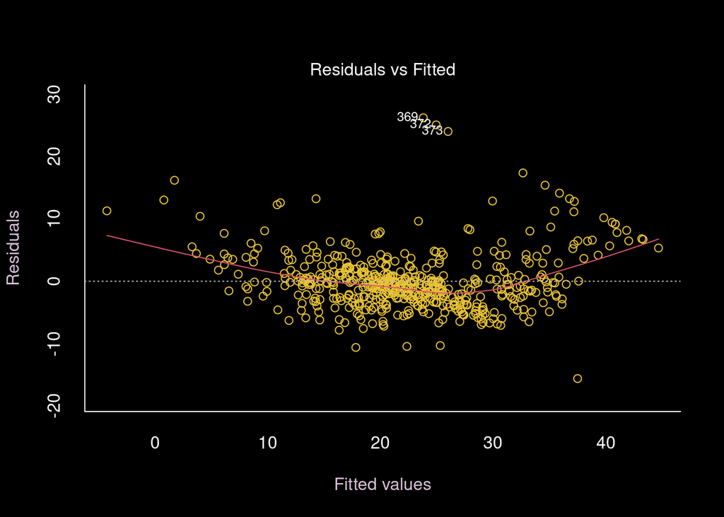

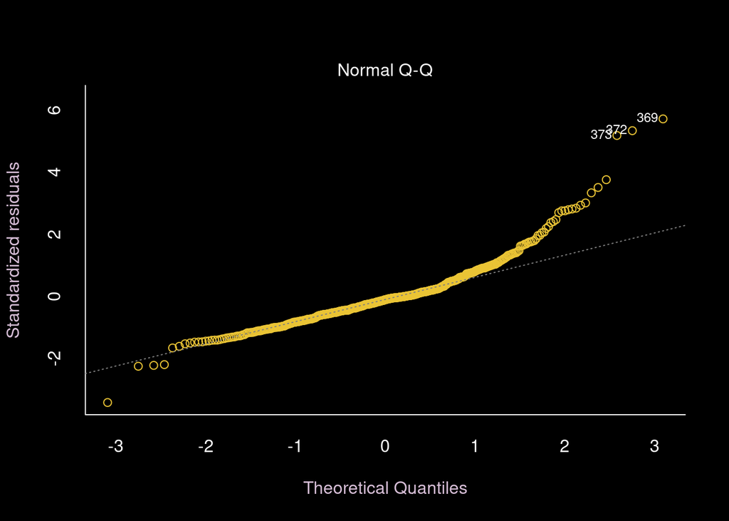

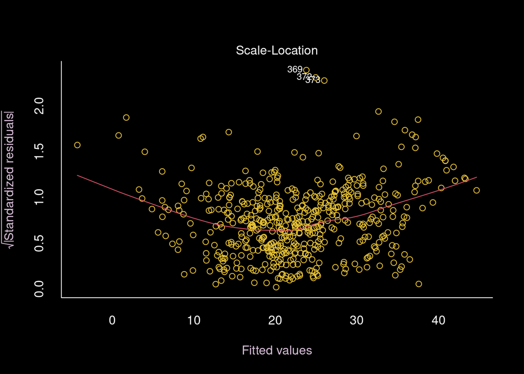

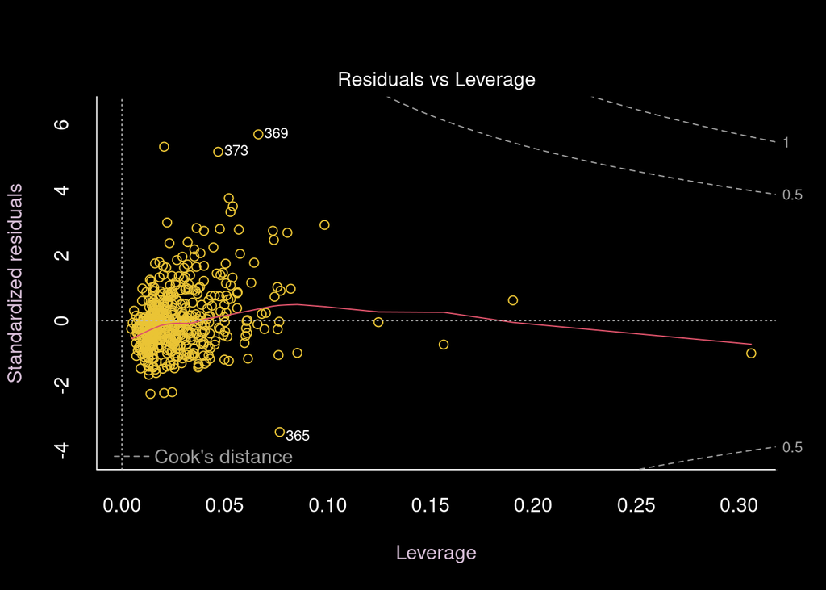

```r
op <- par(bg = '#000000')

graphics::par(mfrow = c(1,1), bty = 'l', col = '#FFFFFF')
plot(mod_completo, bg = par('bg'), col = '#EAC435', col.axis = "#FFFFFF", col.lab = "thistle")
```

Verificar a existência de correlação entre as variáveis

```r
x <- MASS::Boston[1:13]

caret::findLinearCombos(x)
```

```
## $linearCombos
## list()
##
## $remove
## NULL
```

```r
car::vif(mod_completo)
```

```
##     crim       zn    indus     chas      nox       rm      age      dis
## 1.792192 2.298758 3.991596 1.073995 4.393720 1.933744 3.100826 3.955945
##      rad      tax  ptratio    black    lstat
## 7.484496 9.008554 1.799084 1.348521 2.941491
```

## Referências Bibliográficas

Morettin, Pedro Alberto, and Singer, Julio da Motta. 2022. *Estatística e Ciência de Dados*. First. Rio de Janeiro: LTC - Livros Técnicos e Científicos Editora Ltda.

Pianezzer, Guilherme Augusto. 2020. *Modelagem Estatística*. First. Vol. 1. Curitiba: Contentus.

“Understanding Diagnostic Plots for Linear Regression Analysis | University of Virginia Library Research Data Services + Sciences.” n.d. https://data.library.virginia.edu/diagnostic-plots/.